# Alien conifers

NO_AATS_002

Authors

Affiliations

Aud Helen Halbritter

University of Bergen

Ulrika Jansson Asplund

Norwegian Institute for Nature Research

Erik Framstad

Norwegian Institute for Nature Research

Oliver Snoksrud

Norwegian Institute of Bioeconomy Research

Ken Olaf Storaunet

Norwegian Institute of Bioeconomy Research

Published

May 11, 2026

> **Recommended citation**: Halbritter, A. H., Jansson Asplund, U., Framstad, E., Snoksrud, O., and Storaunet, K. O. 2026. Alien conifers (ID(s): NO_AATS_002) v. 000.002. ecRxiv: https://github.com/NINAnor/ecRxiv/tree/main/indicators/NO_AATS_002

**TipMetadata**

Table 1: Indicator metadata

[output not shown]

**TipLog**

- 26 Oct. 2025 - Original PR
- 11 May. 2026 - Updated version to new template
- 8 Jun. 2026 - Change indicator from absence to share of alien coniferous tree species; national refs *X<sub>0</sub>* = 50%, *X<sub>100</sub>* = 0%; ecTools workflow
- 2 Jul. 2026 - Finalize text and references

## 1. Summary

1. **Background and rationale**:

Many non-native or alien tree species are considered to have a high ecological risk for native forest ecosystems. Intact ecosystems should not contain non-native or alien coniferous tree species. This indicator is specified as the percentage share of alien coniferous tree species in the forest, and represents the non-native tree species considered to have an ecological risk (Artsdatabanken 2023). Data for this indicator come from the National Forest Inventory (NFI), where all trees larger than 5 cm at breast height (dbh) have been recorded within the 250 m² NFI plots since ca. 1990 (Viken 2025). The planting of non-native tree species in forestry is the most important anthropogenic driver for this indicator.

2. **Methods**:

All trees larger than 5 cm at breast height (dbh) are recorded and identified to species for each 250 m² NFI inventory plot. There are about 12,000 NFI plots in forest ecosystems, distributed on a regular grid, sampled over a 5-year period with a representative sampling scheme every year. For each reporting period, the indicator is the area-weighted mean percentage tree dominance of alien coniferous species across NFI plots in the selected geographic unit. The share is derived from NFI variables for non-native *Picea spp*. , *Abies spp.* and *Pinus spp.*. Within selected municipalities (along the coast) where Norway spruce (*Picea abies*) is considered non-native (following Øyen and Nygaard (2020)), this species is also included in the share of non-native trees. Results are calculated for 5-year periods (2010–2014, 2015–2019, 2020–2024) and scaled to 0–1 against national reference levels.

3. **Interpretation**:

An indicator value of 1 corresponds to 0% alien coniferous species (*X<sub>100</sub>*). An indicator value of 0 corresponds to 50% or more alien coniferous species (*X<sub>0</sub>*). Values between 0 and 1 reflect intermediate shares on a linear scale between the national reference levels. The relationship between indicator values and ecosystem condition is assumed to be linear.

4. **Results and development needs**:

### 1.2 Native language summary - Norwegian

**Bakgrunn og begrunnelse**: Fremmede treslag kan utgjøre en risiko for naturlige skogøkosystemer. Intakte økosystemer inneholder ikke fremmede bartreslag.

**Metoder**: Indikatoren er angitt som andel (%) fremmede bartrær i Landsskogtakseringens prøveflater, der alle trær ≥5 cm er registrert siden ca. 1990., basert på LSKs variabler for innførte gran- og furu-treslag (`intro_gran_pr`og `intro_furu_pr`). I utvalgte kommuner langs kysten der vanlig gran er ansett som ikke naturlig forekommende (ihht. Øyen and Nygaard (2020)) inngår også gran (*Picea abies*) i indikatoren. For hver rapporteringsperiode beregnes arealvektede gjennomsnitt for fylker, regioner og nasjonalt nivå med au_al. Verdiene skaleres lineært mot nasjonale referansenivå.

**Tolkning**: Indikatorverdi 1 tilsvarer 0 % fremmede bartrær (*X<sub>100</sub>*). Indikatorverdi 0 tilsvarer 50 % eller mer fremmede bartrær (*X<sub>0</sub>*).

## 2. About the underlying data

### 2.1 Spatial and temporal resolution and extent

Data are available from 2010, when the NFI grid was extended to all forest land. Annual estimates are possible due to representative sampling every year. The analyses use 5-year reporting periods from 2010 onwards (2010-2014, 2015-2019, and 2020-2024). The data are representative for all forest land within the selected region. Spatial resolution should be limited to counties.

### 2.2 Sampling design

All trees larger than 5 cm at breast height (dbh) are recorded and identified to species for each 250 m² NFI inventory plot (Viken 2025). There are about 12,000 NFI plots in forest ecosystems, distributed on a regular grid, with varying coverage for forest below/above the coniferous forest line and in Finnmark county. All NFI plots are sampled over a 5-year period, with a representative sampling scheme every year, allowing unbiased estimates from data for each year.

### 2.3 Original units

The indicator is specified as the percentage share of alien coniferous species, derived from the percentage of the volume (cutting class 3–5) or crown cover (cutting class 2) of introduced coniferous tree species (NFI variables `intro_gran_pr`, `intro_furu_pr`). Within selected municipalities (along the coast) where Norway spruce (*Picea abies*) is considered non-native (`komm_m_nat_gran`), this species is also included in the percentage. At plot level this is a percentage (0–100); aggregated values are area-weighted means of that percentage.

### 2.4 Instructions for citing, using and accessing data

The data used for this indicator have been made available by the Norwegian National Forest Inventory under a specific data use agreement of 2026-05-29, between NIBIO and the specified users. Further use of these data requires a separate data user agreement with NIBIO.

## 3. Indicator properties

### 3.2 Ecosystem condition characteristic

### 3.3 Collinearities with other indicators

There may be some positive correlation with the indicator for alien plant species in the field layer, although this indicators use other data and sampling design.

### 3.4 Impact factors

The planting of alien tree species in forestry is the most important anthropogenic driver for this indicator, although such planting has been reduced last decades. Harvested alien tree species may to some extent be replaced by native species. Natural disturbances and long-term shifts in climate conditions may increase the possibility for alien species to spread and establish in other ecosystems. Planting of exotic trees in parks, gardens etc. will establish a source of such species that might spread into forest ecosystems.

### 3.5 Spatial aggregation

The spatial aggregation pathway is Aggregate (NFI plots to county) – [Scale – Truncate] – Aggregate (geographic region) – Aggregate (national level). For each reporting period, non-scaled values for county, region, and Norway are obtained by pooling all included forest plots in the unit: the area-weighted mean of the plot-level alien coniferous share (%). Where NFI county labels are split into parts, those labels are merged to a single county name before aggregation. Scaling and truncation are applied after non-scaled county aggregates have been calculated: each county is scaled against the national lower reference level *X<sub>0</sub>* (50% alien conifers) and upper reference level *X<sub>100</sub>* (0% alien conifers) using a linear scaling function, and values outside [0, 1] are truncated at that step. Regional and national scaled point estimates are area-weighted means of the already scaled county values, using each county’s represented area as weight. The indicator is likely to have a high frequency of NFI plots without any recorded alien coniferous species, so results should not be interpreted at finer resolution than counties.

## 4. Reference condition and levels

### 4.1 Reference condition

The reference condition is considered to be intact forest ecosystems, where effects of human activities are clearly subordinate to those of natural ecosystem processes and disturbances.

### 4.2 Reference levels

Intact forest ecosystems do not have alien coniferous tree species. The upper reference value (*X<sub>100</sub>*) is therefore 0% alien coniferous species. The lower reference value (*X<sub>0</sub>*) is set to 50% alien coniferous species. The *X<sub>0</sub>* value of 50% relates to the Natur-i-Norge definitions of the difference between [NA-TB01](https://artsdatabanken.no/naturtyper/natur-i-norge/NIN-3.0-T-C-PE-NA-MB-A-TB01) (Fastmarksskogsmark) and [NA-TI01](https://artsdatabanken.no/naturtyper/natur-i-norge/NIN-3.0-T-C-PE-NA-MB-A-TI01) (Klart endret skogsmark). The same *X<sub>0</sub>* and *X<sub>100</sub>* are applied when scaling each county before regional and national aggregation. For lack of better knowledge, a linear relationship is assumed between *X<sub>0</sub>* and *X<sub>100</sub>*. Hence, indicator values are scaled between 0 and 1 based on a linear scaling function; scaled indicator values outside [0, 1] are truncated at scaling.

#### 4.2.1 Spatial resolution and validity

Reference levels are defined as one national value for alien coniferous share (0%). Although indicator values from NFI plots may technically be aggregated at finer spatial units than counties, scaling at such finer levels may result in biases.

## 5. Uncertainties

### 5.1 General uncertainties

Uncertainties relate to the variability in the frequency of alien species among NFI plots and recording errors for tree species within NFI plots. There is also uncertainty related to the setting of the reference values and to the shape of the relationship between indicator values and ecosystem condition. These uncertainties are not quantified.

### 5.2 Reported uncertainties

The uncertainties reported in Section 10 are inferential and refer to uncertainty around the point estimates, not to the full spatial variation among NFI plots. For each reporting period, non-scaled indicator values are bootstrapped by resampling NFI plots with replacement within each county and recalculating the area-weighted mean alien coniferous share. For scaled county values, bootstrap draws are transformed using the same national reference levels *X<sub>0</sub>* and *X<sub>100</sub>* as the point estimates (truncation at scaling). For scaled regional and national values, uncertainty is propagated from the scaled county bootstrap draws. The resulting distributions are summarised with median and quantile intervals.

## 6. References

Artsdatabanken. 2023. [Fremmede arter i norge — med økologisk risiko 2023](http://www.artsdatabanken.no/lister/fremmedartslista/2023).

Øyen, B.-H., and P. H. Nygaard. 2020. *[Naturlig utbredelse av gran i norge](https://nva.sikt.no/registration/0198cc627d33-ef567030-f3ea-46cf-af79-b8d3b70a31ae)*. Rapport 6/111. NIBIO.

Viken, K. O. 2025. *Landsskogtakseringens feltinstruks — 2025*. Vol. 11. 8. NIBIO Bok.

## 7. Import and prepare datasets

### 7.1 Alien coniferous tree species

All trees larger than 5 cm dbh are recorded and identified for each 250 m² NFI plot according to methods described in (Viken (2025)). For this indicator, data for the NFI variables `gran_pr`, `intro_gran_pr`, `intro_furu_pr`, and `komm_m_nat_gran` are used for the reporting periods defined in section 9.1. Plots with missing species-percentage values are included in aggregated estimates with 0% share and full plot area weight. Aggregated area-weighted data must be used for appropriate spatial units such as counties, regions or the whole country. As the NFI plots vary in density for forest below/above the coniferous forest line and in Finnmark, each type of plot represents a different part of all forest land. In addition, some NFI plots are divided in two parts in the data. These variations in plot representativity must be accounted for in aggregated estimates. Data from NFI contain an area-weighting variable to be used in aggregating NFI data for spatial units larger than individual NFI plots.

**Load data**

```r
lsk_data_file <- here("data/LSK_data_okologisk_tilstand_2026-06-03.csv")
aats_cache_deps <- c(
  lsk_data_file,
  here::here("R/functions.R"),
  here::here("R/NO_AATS_002.qmd")
)

lsk_data_raw <- read_csv(
  lsk_data_file,
  show_col_types = FALSE,
  locale = locale(encoding = "UTF-8")
) |>
  clean_names()
```

## 8. Spatial units

Aggregated indicator values should not be applied for spatial units finer than those that allow reliable estimates, probably counties (i.e., de facto Ecosystem Assets).

## 9. Analyses

### 9.1 Prepare data and create derived variables

This section prepares the NFI plot data for calculating the indicator.

First we define the 5-year reporting periods that match the temporal structure of the indicator.

**Define reporting periods**

```r
reporting_periods <- list(
  "2010-2014" = 2010:2014,
  "2015-2019" = 2015:2019,
  "2020-2024" = 2020:2024
)
```

We keep data from 2010 onward and standardise county names by merging split NFI labels to county level. Missing (`NA`) values for `gran_pr`, `intro_gran_pr`, and `intro_furu_pr` are set to 0 before aggregation, so these plots remain in the area basis (`au_areal`) with 0% alien coniferous share (missing values occur mainly in harvest class 1 stands). The plot-level indicator depends on `komm_m_nat_gran`: when `n` (no natural spruce), the share is `pmin(gran_pr + intro_gran_pr + intro_furu_pr, 100)`; when `j` (natural spruce present), it is `pmin(intro_gran_pr + intro_furu_pr, 100)`. For each included plot, the area-weighted contribution to later aggregation is `indicator_continuous * au_areal`.

**Create derived variables**

```r
lsk_data <- lsk_data_raw |>
  filter(sesong >= 2010) |>
  mutate(
    gran_pr = dplyr::coalesce(gran_pr, 0),
    intro_gran_pr = dplyr::coalesce(intro_gran_pr, 0),
    intro_furu_pr = dplyr::coalesce(intro_furu_pr, 0),
    fylke_name = region_fylke |>
      stringr::str_remove("^\\d+-\\d+\\s+") |>
      stringr::str_remove("^\\d+\\s*") |>
      stringr::str_squish(),
    fylke_name = normalize_county_parts(fylke_name),
    fylke_name_clean = stringi::stri_trans_general(
      stringr::str_squish(
        tolower(stringr::str_replace_all(fylke_name, "[0-9.-]", " "))
      ),
      "Latin-ASCII"
    ),
    region_code = assign_region_code(fylke_name_clean),
    region_name = assign_region_name(region_code),
    alien_conif_share = dplyr::case_when(
      komm_m_nat_gran == "n" ~ gran_pr + intro_gran_pr + intro_furu_pr,
      TRUE ~ intro_gran_pr + intro_furu_pr
    ),
    indicator_continuous = pmin(alien_conif_share, 100),
    indicator_continuous_weighted = indicator_continuous * au_areal
  )
```

Finally, we retain only the columns required for subsequent aggregation and reporting.

**Select downstream fields**

```r
lsk_data <- lsk_data |>
  dplyr::select(
    sesong,
    au_areal,
    komm_m_nat_gran,
    gran_pr,
    intro_gran_pr,
    intro_furu_pr,
    alien_conif_share,
    indicator_continuous,
    indicator_continuous_weighted,
    region_fylke,
    region_code,
    region_name,
    fylke_name,
    fylke_name_clean
  )
```

### 9.2 Calculate non-scaled area-weighted indicator values

For each reporting period, we calculate non-scaled indicator values separately for counties, regions, and the whole country. Within each geographic unit, the point estimate is the area-weighted arithmetic mean of all NFI plots in that unit: sum of `indicator_continuous_weighted` divided by sum of `au_areal`.

**Calculate non-scaled values**

```r
aats_results <- purrr::imap(
  reporting_periods,
  ~ calculate_period_indicators(lsk_data, .y, .x)
) |>
  purrr::compact()

aats_results_county_all_periods   <- purrr::map_dfr(aats_results, "county")
aats_results_region_all_periods   <- purrr::map_dfr(aats_results, "region")
aats_results_national_all_periods <- purrr::map_dfr(aats_results, "national")
```

### 9.3 Bootstrap draws per county

For each county and period, NFI plots are resampled with replacement 1000 times. Each replicate computes the area-weighted non-scaled mean alien coniferous share (%), giving a distribution of 1000 draws per county.

**Bootstrap draws per county (1000 per county per period)**

```r
county_draws_long <- purrr::imap_dfr(aats_results, function(period_result, period_name) {
  county_meta <- period_result$county |>
    dplyr::select(fylke_name, total_area, region_code)

  purrr::imap_dfr(
    split(period_result$data, period_result$data$fylke_name),
    function(county_data, county_name) {
      boot <- bootstrap_indicator(county_data, n_bootstrap = 1000)
      dplyr::tibble(
        period           = period_name,
        fylke_name       = county_name,
        sim_id           = seq_along(boot$draws),
        non_scaled_value = boot$draws
      )
    }
  ) |>
    dplyr::left_join(county_meta, by = "fylke_name")
})
```

The table below (Table 2) shows the direct area-weighted mean alien coniferous share per county for all reporting periods, with approximate 95% bootstrap confidence intervals (2.5th–97.5th percentile of 1000 draws). Use the search box and page controls to browse rows.

Table 2: Non-scaled alien coniferous tree species share (%) by county for all reporting periods. Point estimate is the direct area-weighted mean from section 9.2; 95% CI is derived from 1000 bootstrap draws.

| Period | County | Region | Alien conifers (%) | 95% CI | Total area (ha) | Number of plots |
| --- | --- | --- | --- | --- | --- | --- |
| 2010-2014 | Buskerud | Øst | 0.04 | 0 – 0.12 | 763374.1106 | 860 |
| 2010-2014 | Hedmark | Øst | 0.25 | 0.09 – 0.43 | 1701403.555 | 1904 |
| 2010-2014 | Oppland | Øst | 0.24 | 0.03 – 0.48 | 988332.071 | 1082 |
| 2010-2014 | Oslo og Akershus | Øst | 0.02 | 0 – 0.06 | 345444.5254 | 425 |
| 2010-2014 | Vestfold | Øst | 0.02 | 0 – 0.07 | 139872.1376 | 171 |
| 2010-2014 | Østfold | Øst | 0 | 0 – 0 | 271633.1332 | 327 |
| 2010-2014 | Agder | Sør | 0.33 | 0.07 – 0.71 | 882846.0262 | 987 |
| 2010-2014 | Telemark | Sør | 0 | 0 – 0.01 | 807800.106 | 912 |
| 2010-2014 | Hordaland | Vest | 7.35 | 5.46 – 9.44 | 449686.9738 | 507 |
| 2010-2014 | Rogaland | Vest | 8.16 | 5.5 – 11.36 | 258352.5786 | 258 |

[output cut: 38 more lines]

### 9.4 Scale indicator values and aggregate to regional and national levels

National reference levels are *X<sub>0</sub>* = 50% alien coniferous species (worst condition) and *X<sub>100</sub>* = 0% alien coniferous species (best condition).

**National reference levels**

```r
x0 <- 50
x100 <- 0
```

Each county’s 1000 non-scaled draws from section 9.3 are scaled with `ecTools::ec_normalise()` (linear, *X<sub>0</sub>* = 50%, *X<sub>100</sub>* = 0%; truncation at scaling). Figure 1 shows the mapping.

**Scale county draws; derive county uncertainty and feed ec_upscale**

```r
county_draws_scaled <- county_draws_long |>
  dplyr::mutate(
    scaled_value = ec_normalise(
      non_scaled_value,
      x0 = x0,
      x100 = x100,
      fun = "linear"
    ),
    nation = "National"
  )

county_scaled_with_uncertainty <- county_draws_scaled |>
  dplyr::group_by(period, fylke_name, total_area, region_code) |>
  dplyr::summarise(
    median = median(scaled_value),
    p_025  = as.numeric(quantile(scaled_value, 0.025)),
    p_25   = as.numeric(quantile(scaled_value, 0.25)),
    p_75   = as.numeric(quantile(scaled_value, 0.75)),
    p_975  = as.numeric(quantile(scaled_value, 0.975)),
    .groups = "drop"
  ) |>
  dplyr::left_join(
    aats_results_county_all_periods |> dplyr::select(period, fylke_name, n_plots),
    by = c("period", "fylke_name")
  )
```

**Normalisation diagnostic figure**

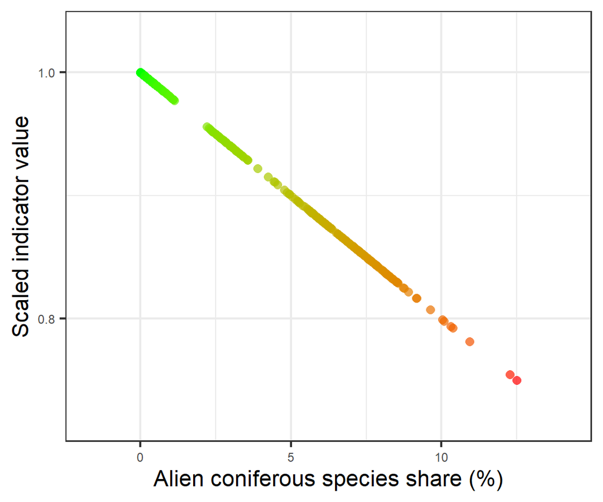

```r
norm_plot_data <- county_draws_scaled |>
  dplyr::slice_sample(n = min(500, nrow(county_draws_scaled)))

aats_norm_plot <- ec_norm_plot(norm_plot_data$non_scaled_value, norm_plot_data$scaled_value) +
  ggplot2::labs(
    x = "Alien coniferous species share (%)",
    y = "Scaled indicator value"
  ) +
  ggplot2::theme(axis.text = ggplot2::element_text(size = 9))
aats_norm_plot$layers[[1]]$aes_params$size <- 3

suppressMessages(
  ggsave(
    filename = here::here("img/aats_norm_plot.png"),
    plot = aats_norm_plot,
    scale = 1.5
  )
)

aats_norm_plot
```

The scaled draws are then passed to `ecTools::ec_upscale()`, which propagates uncertainty through the spatial hierarchy. For each of 1000 Monte Carlo iterations, one draw is sampled per county and the area-weighted mean gives one regional value; a second `ec_upscale()` call repeats this from regions to national level.

**ec_upscale: county to region**

```r
aats_mc_rds_regional <- here::here("data/aats_mc_regional.rds")

aats_mc_regional <- ecTools::ec_upscale(
  data        = county_draws_scaled,
  variable    = scaled_value,
  weight      = total_area,
  start_units = fylke_name,
  end_units   = region_code,
  year        = period,
  end_units_name = "region_code",
  n = 1000
)
saveRDS(aats_mc_regional, aats_mc_rds_regional)
```

**ec_upscale: region to national**

```r
region_area_weights <- county_draws_scaled |>
  dplyr::distinct(period, fylke_name, total_area, region_code) |>
  dplyr::group_by(period, region_code) |>
  dplyr::summarise(region_area = sum(total_area), .groups = "drop")

aats_mc_regional_for_national <- aats_mc_regional |>
  dplyr::left_join(region_area_weights, by = c("period", "region_code")) |>
  dplyr::mutate(nation = "National")

aats_mc_rds_national <- here::here("data/aats_mc_national.rds")

aats_mc_national <- ecTools::ec_upscale(
  data        = aats_mc_regional_for_national,
  variable    = sampled_mean,
  weight      = region_area,
  start_units = region_code,
  end_units   = nation,
  year        = period,
  end_units_name = "nation",
  n = 1000
)
saveRDS(aats_mc_national, aats_mc_rds_national)
```

**Combine regional and national MC draws; build summary tables**

```r
aats_mc_combined <- dplyr::bind_rows(
  aats_mc_regional |> dplyr::select(period, region = region_code, sampled_mean),
  aats_mc_national |> dplyr::select(period, region = nation, sampled_mean)
)

county_scaled_all_periods <- aats_results_county_all_periods |>
  dplyr::mutate(
    scaled_value = ec_normalise(indicator_value, x0 = x0, x100 = x100, fun = "linear")
  )

region_scaled_agg_all_periods <- aats_mc_regional |>
  dplyr::group_by(period, region_code) |>
  dplyr::summarise(scaled_value = median(sampled_mean), .groups = "drop") |>
  dplyr::mutate(region_name = assign_region_name(region_code))

national_scaled_agg_all_periods <- aats_mc_national |>
  dplyr::group_by(period) |>
  dplyr::summarise(scaled_value = median(sampled_mean), .groups = "drop") |>
  dplyr::mutate(region = "National")

region_scaled_agg_with_uncertainty <- aats_mc_regional |>
  dplyr::group_by(period, region_code) |>
  dplyr::summarise(
    median = median(sampled_mean),
    p_025  = as.numeric(quantile(sampled_mean, 0.025)),
    p_25   = as.numeric(quantile(sampled_mean, 0.25)),
    p_75   = as.numeric(quantile(sampled_mean, 0.75)),
    p_975  = as.numeric(quantile(sampled_mean, 0.975)),
    .groups = "drop"
  ) |>
  dplyr::mutate(region_name = assign_region_name(region_code)) |>
  dplyr::left_join(
    aats_results_region_all_periods |> dplyr::select(period, region_code, total_area, n_plots),
    by = c("period", "region_code")
  )

national_scaled_agg_with_uncertainty <- aats_mc_national |>
  dplyr::group_by(period) |>
  dplyr::summarise(
    median = median(sampled_mean),
    p_025  = as.numeric(quantile(sampled_mean, 0.025)),
    p_25   = as.numeric(quantile(sampled_mean, 0.25)),
    p_75   = as.numeric(quantile(sampled_mean, 0.75)),
    p_975  = as.numeric(quantile(sampled_mean, 0.975)),
    .groups = "drop"
  ) |>
  dplyr::mutate(region = "National") |>
  dplyr::left_join(
    aats_results_national_all_periods |> dplyr::select(period, total_area, n_plots),
    by = "period"
  )

truncation_summary <- dplyr::bind_rows(
  aats_results_county_all_periods |>
    dplyr::mutate(
      level = "County",
      exceeds_threshold = indicator_value > x0,
      original_value_pct = round(indicator_value, 2),
      reference_value_pct = x0,
      region_code = NA_character_,
      region_name = NA_character_
    ) |>
    dplyr::select(
      period, level, region_code, region_name, fylke_name,
      reference_value_pct, exceeds_threshold, original_value_pct
    ),
  region_scaled_agg_all_periods |>
    dplyr::left_join(
      aats_results_region_all_periods |> dplyr::select(period, region_code, indicator_value),
      by = c("period", "region_code")
    ) |>
    dplyr::mutate(
      level = "Region",
      exceeds_threshold = scaled_value >= 1,
      original_value_pct = round(indicator_value, 2),
      reference_value_pct = NA_real_,
      fylke_name = NA_character_
    ) |>
    dplyr::select(
      period, level, region_code, region_name, fylke_name,
      reference_value_pct, exceeds_threshold, original_value_pct
    ),
  national_scaled_agg_all_periods |>
    dplyr::left_join(
      aats_results_national_all_periods |> dplyr::select(period, indicator_value),
      by = "period"
    ) |>
    dplyr::mutate(
      level = "National",
      exceeds_threshold = scaled_value >= 1,
      original_value_pct = round(indicator_value, 2),
      reference_value_pct = NA_real_,
      region_code = NA_character_,
      region_name = "National",
      fylke_name = NA_character_
    ) |>
    dplyr::select(
      period, level, region_code, region_name, fylke_name,
      reference_value_pct, exceeds_threshold, original_value_pct
    )
)

truncation_counts <- truncation_summary |>
  dplyr::group_by(period, level) |>
  dplyr::summarise(
    n_total = dplyr::n(),
    n_exceeding_reference = sum(exceeds_threshold, na.rm = TRUE),
    pct_exceeding_reference = round(100 * n_exceeding_reference / n_total, 1),
    .groups = "drop"
  )

truncated_values <- truncation_summary |>
  dplyr::filter(exceeds_threshold) |>
  dplyr::arrange(period, level, dplyr::desc(original_value_pct))
```

At county level, truncation is evaluated by comparing the non-scaled point estimate to *X<sub>0</sub>* (50%). At regional and national level, the tables report cases where the `ec_upscale()` median equals 1.

| Period | Level | Total | Exceeding reference | % Exceeding reference |
| --- | --- | --- | --- | --- |
| 2010-2014 | County | 16 | 0 | 0.0 |
| 2010-2014 | National | 1 | 0 | 0.0 |
| 2010-2014 | Region | 5 | 0 | 0.0 |
| 2015-2019 | County | 16 | 0 | 0.0 |
| 2015-2019 | National | 1 | 0 | 0.0 |
| 2015-2019 | Region | 5 | 0 | 0.0 |
| 2020-2024 | County | 16 | 0 | 0.0 |
| 2020-2024 | National | 1 | 0 | 0.0 |
| 2020-2024 | Region | 5 | 0 | 0.0 |

```
No values exceeded _X~0~_ (50%) and required truncation.
```

The time series below (Figure 2) summarises regional and national values.

**Time series of indicator values by region and period**

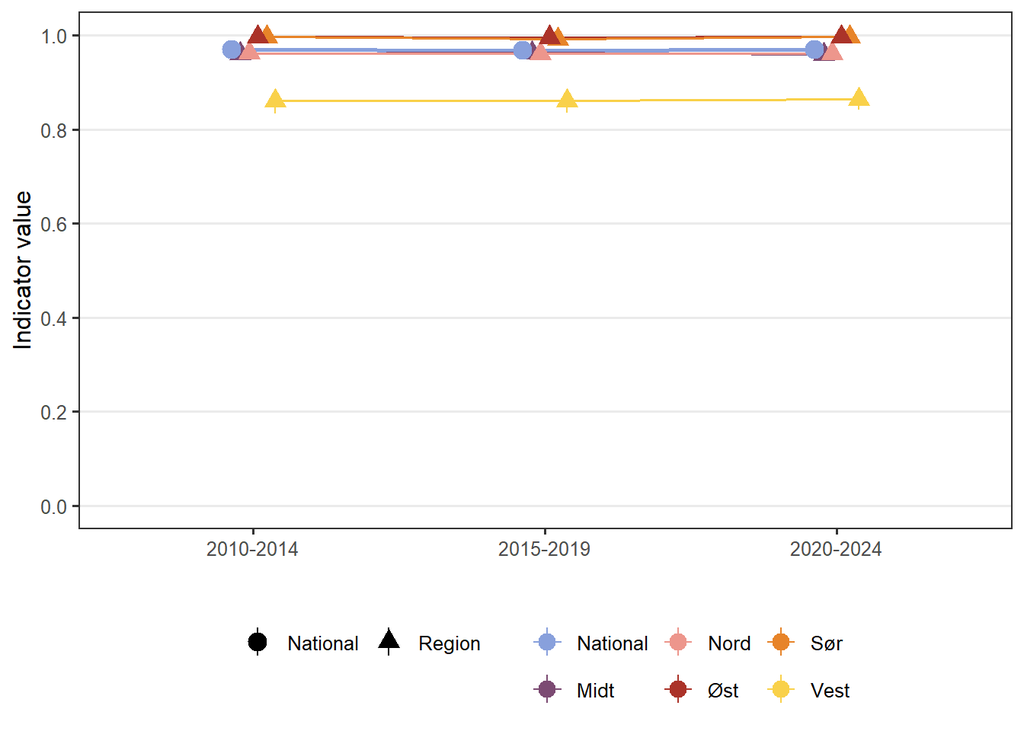

Figure 2: Indicator values for alien coniferous tree species by region and reporting period. Points show the MC median; error bars are 95% credible intervals from the Monte Carlo propagation. National values use filled circles and a thicker line.

```r
aats_region_labels <- c(
  "1" = "Øst", "2" = "Sør", "3" = "Vest",
  "4" = "Midt", "5" = "Nord", "National" = "National"
)
aats_region_levels <- c("National", "Midt", "Nord", "Øst", "Sør", "Vest")
aats_region_cols <- setNames(
  MetBrewer::met.brewer("Archambault", n = length(aats_region_levels)),
  aats_region_levels
)

aats_plot_data <- aats_mc_combined |>
  dplyr::mutate(
    region_name = dplyr::recode(region, !!!aats_region_labels),
    series_type = dplyr::if_else(region == "National", "National", "Region")
  ) |>
  dplyr::group_by(period, region_name, series_type) |>
  dplyr::summarise(
    median = median(sampled_mean),
    p_025  = as.numeric(quantile(sampled_mean, 0.025)),
    p_975  = as.numeric(quantile(sampled_mean, 0.975)),
    .groups = "drop"
  ) |>
  dplyr::mutate(region_name = factor(region_name, levels = aats_region_levels))

ggplot2::ggplot(
  aats_plot_data,
  ggplot2::aes(x = period, y = median, colour = region_name, group = region_name)
) +
  ggplot2::geom_line(
    ggplot2::aes(linewidth = series_type),
    position = ggplot2::position_dodge(width = 0.18)
  ) +
  ggplot2::geom_pointrange(
    ggplot2::aes(ymin = p_025, ymax = p_975, shape = series_type),
    size = 0.8, linewidth = 0.45,
    position = ggplot2::position_dodge(width = 0.18)
  ) +
  ggplot2::scale_colour_manual(values = aats_region_cols, name = NULL) +
  ggplot2::scale_shape_manual(values = c(National = 19, Region = 17), name = NULL) +
  ggplot2::scale_linewidth_manual(values = c(National = 1, Region = 0.55), guide = "none") +
  ggplot2::scale_y_continuous(limits = c(0, 1), breaks = seq(0, 1, 0.2)) +
  ggplot2::theme_bw(base_size = 12) +
  ggplot2::theme(
    legend.position    = "bottom",
    legend.box         = "horizontal",
    panel.grid.minor   = ggplot2::element_blank(),
    panel.grid.major.x = ggplot2::element_blank()
  ) +
  ggplot2::guides(
    colour = ggplot2::guide_legend(
      nrow = 2,
      override.aes = list(size = 0.7, linewidth = 0.45)
    ),
    shape  = ggplot2::guide_legend(override.aes = list(size = 0.8, linewidth = 0.45))
  ) +
  ggplot2::labs(y = "Indicator value", x = "")
```

## 10. Results

The following tables present scaled indicator results at county, regional, and national scales for each reporting period. Tables report the median as the indicator value, with an approximate 95% interval (2.5% and 97.5% quantiles) and an approximate interquartile range (25% and 75% quantiles). All scaled values are on a 0–1 scale, where 0 corresponds to *X<sub>0</sub>* (50% alien coniferous share) and 1 corresponds to *X<sub>100</sub>* (0% alien coniferous share).

### 10.1 County-level results (scaled with uncertainty)

Use the search box and page controls in Table 3 to browse county rows across all reporting periods.

Table 3: County indicator values for alien coniferous tree species by reporting period. Values are scaled to 0–1 using national *X<sub>0</sub>* and *X<sub>100</sub>*. Uncertainty is derived from 1000 bootstrap draws. The median is reported as the indicator value, with approximate 95% and interquartile intervals from the scaled draw distribution.

| ECT | Indicator | ID | Accounting area | Region | Ecosystem | Reporting period | Indicator value | 95% CI | 50% CI | Number of plots |
| --- | --- | --- | --- | --- | --- | --- | --- | --- | --- | --- |
| B1 | Alien coniferous tree species | NO_AATS_002 | Buskerud | Øst | Boreal/montane forests | 2010-2014 | 1 | 1 - 1 | 1 - 1 | 860 |
| B1 | Alien coniferous tree species | NO_AATS_002 | Hedmark | Øst | Boreal/montane forests | 2010-2014 | 1 | 0.99 - 1 | 0.99 - 1 | 1904 |
| B1 | Alien coniferous tree species | NO_AATS_002 | Oppland | Øst | Boreal/montane forests | 2010-2014 | 1 | 0.99 - 1 | 0.99 - 1 | 1082 |
| B1 | Alien coniferous tree species | NO_AATS_002 | Oslo og Akershus | Øst | Boreal/montane forests | 2010-2014 | 1 | 1 - 1 | 1 - 1 | 425 |
| B1 | Alien coniferous tree species | NO_AATS_002 | Vestfold | Øst | Boreal/montane forests | 2010-2014 | 1 | 1 - 1 | 1 - 1 | 171 |
| B1 | Alien coniferous tree species | NO_AATS_002 | Østfold | Øst | Boreal/montane forests | 2010-2014 | 1 | 1 - 1 | 1 - 1 | 327 |
| B1 | Alien coniferous tree species | NO_AATS_002 | Agder | Sør | Boreal/montane forests | 2010-2014 | 0.99 | 0.99 - 1 | 0.99 - 1 | 987 |
| B1 | Alien coniferous tree species | NO_AATS_002 | Telemark | Sør | Boreal/montane forests | 2010-2014 | 1 | 1 - 1 | 1 - 1 | 912 |
| B1 | Alien coniferous tree species | NO_AATS_002 | Hordaland | Vest | Boreal/montane forests | 2010-2014 | 0.85 | 0.81 - 0.89 | 0.84 - 0.87 | 507 |
| B1 | Alien coniferous tree species | NO_AATS_002 | Rogaland | Vest | Boreal/montane forests | 2010-2014 | 0.84 | 0.77 - 0.89 | 0.82 - 0.86 | 258 |

[output cut: 38 more lines]

### 10.2 Regional results (scaled with uncertainty)

Table 4: Regional indicator values for alien coniferous tree species by reporting period. Scaled values and uncertainty are derived from Monte Carlo propagation (1000 draws per region per period). The median is reported as the indicator value, with approximate 95% and interquartile intervals from the MC distribution.

| ECT | Indicator | ID | Accounting area | Ecosystem | Reporting period | Indicator value | 95% CI | 50% CI | Number of plots |
| --- | --- | --- | --- | --- | --- | --- | --- | --- | --- |
| B1 | Alien coniferous tree species | NO_AATS_002 | Øst | Boreal/montane forests | 2010-2014 | 1.00 | 0.99 - 1 | 1 - 1 | 4,769 |
| B1 | Alien coniferous tree species | NO_AATS_002 | Sør | Boreal/montane forests | 2010-2014 | 1.00 | 0.99 - 1 | 1 - 1 | 1,899 |
| B1 | Alien coniferous tree species | NO_AATS_002 | Vest | Boreal/montane forests | 2010-2014 | 0.86 | 0.83 - 0.88 | 0.85 - 0.87 | 1,243 |
| B1 | Alien coniferous tree species | NO_AATS_002 | Midt | Boreal/montane forests | 2010-2014 | 0.96 | 0.95 - 0.97 | 0.96 - 0.96 | 2,384 |
| B1 | Alien coniferous tree species | NO_AATS_002 | Nord | Boreal/montane forests | 2010-2014 | 0.96 | 0.95 - 0.97 | 0.96 - 0.96 | 2,172 |
| B1 | Alien coniferous tree species | NO_AATS_002 | Øst | Boreal/montane forests | 2015-2019 | 1.00 | 0.99 - 1 | 1 - 1 | 4,764 |
| B1 | Alien coniferous tree species | NO_AATS_002 | Sør | Boreal/montane forests | 2015-2019 | 0.99 | 0.99 - 1 | 0.99 - 0.99 | 1,907 |
| B1 | Alien coniferous tree species | NO_AATS_002 | Vest | Boreal/montane forests | 2015-2019 | 0.86 | 0.84 - 0.88 | 0.85 - 0.87 | 1,254 |
| B1 | Alien coniferous tree species | NO_AATS_002 | Midt | Boreal/montane forests | 2015-2019 | 0.96 | 0.95 - 0.97 | 0.96 - 0.97 | 2,390 |
| B1 | Alien coniferous tree species | NO_AATS_002 | Nord | Boreal/montane forests | 2015-2019 | 0.96 | 0.95 - 0.97 | 0.96 - 0.96 | 2,242 |
| B1 | Alien coniferous tree species | NO_AATS_002 | Øst | Boreal/montane forests | 2020-2024 | 1.00 | 0.99 - 1 | 1 - 1 | 4,795 |
| B1 | Alien coniferous tree species | NO_AATS_002 | Sør | Boreal/montane forests | 2020-2024 | 1.00 | 0.99 - 1 | 1 - 1 | 1,908 |
| B1 | Alien coniferous tree species | NO_AATS_002 | Vest | Boreal/montane forests | 2020-2024 | 0.86 | 0.84 - 0.89 | 0.86 - 0.87 | 1,272 |
| B1 | Alien coniferous tree species | NO_AATS_002 | Midt | Boreal/montane forests | 2020-2024 | 0.96 | 0.95 - 0.97 | 0.96 - 0.96 | 2,391 |
| B1 | Alien coniferous tree species | NO_AATS_002 | Nord | Boreal/montane forests | 2020-2024 | 0.96 | 0.95 - 0.97 | 0.96 - 0.96 | 2,241 |

### 10.3 National results (scaled with uncertainty)

Table 5: National indicator values for alien coniferous tree species by reporting period. Scaled values and uncertainty are derived from Monte Carlo propagation (1000 draws). The median is reported as the indicator value, with approximate 95% and interquartile intervals from the MC distribution.

| ECT | Indicator | ID | Accounting area | Ecosystem | Reporting period | Indicator value | 95% CI | 50% CI | Number of plots |
| --- | --- | --- | --- | --- | --- | --- | --- | --- | --- |
| B1 | Alien coniferous tree species | NO_AATS_002 | National | Boreal/montane forests | 2010-2014 | 0.97 | 0.97 - 0.97 | 0.97 - 0.97 | 12,467 |
| B1 | Alien coniferous tree species | NO_AATS_002 | National | Boreal/montane forests | 2015-2019 | 0.97 | 0.96 - 0.97 | 0.97 - 0.97 | 12,557 |
| B1 | Alien coniferous tree species | NO_AATS_002 | National | Boreal/montane forests | 2020-2024 | 0.97 | 0.97 - 0.97 | 0.97 - 0.97 | 12,607 |

## 11. Export file

Regional and national Monte Carlo draws are exported in one table (`aats_mc_combined`: `period`, `region`, `sampled_mean`; `region` contains the five NI region codes and `"National"`).

**Export regional and national MC-propagated indicator draws**

```r
arrow::write_parquet(
  aats_mc_combined,
  here::here("data/results_NO_AATS_002.csv")
)
```

## 12. Author contributions

**CRediT statement**

- Conceptualization: [EF, KOS, UJA]
- Methodology: [EF, KOS]
- Data curation: [OS]
- Formal analysis: [AHH]
- Validation: [AHH, KOS]
- Visualization: [AHH]
- Writing – original draft: [All]
- Writing – review & editing: [All]

**MeRIT attribution**

This part supplements the CRediT statement with more granularity for method section.

**TipSession Info**

This information is mainly aimed at developers that need to recreate the R environment that produced the html. Important note: this information is about the R session that was running when the html was rendered, and if some of the code chunks were not evaluated when the html was rendered, they may have been executed in a different environment.